# Loaded Questions Scoring

July 1, 2020

# Q1: What ordinary thing are you most eagerly anticipating doing when the pandemic ends?

Actual answers:

| Player | Actual answer |
| --- | --- |
| James Chesko | Going bike riding with friends |
| James G | Videogames (at someone else’s house) |
| Jesse | korean bbq |
| Josefin | Hiking with overnight camping |
| Laura | Having friends over to dinner |
| Linxi Zhu | visit my friends |
| Millie | happy hour! |
| Qingxin | Going to a beach park with family |
| Simone | Camping |

Who had the most correct answers? (I ignored small syntax differences when scoring.)

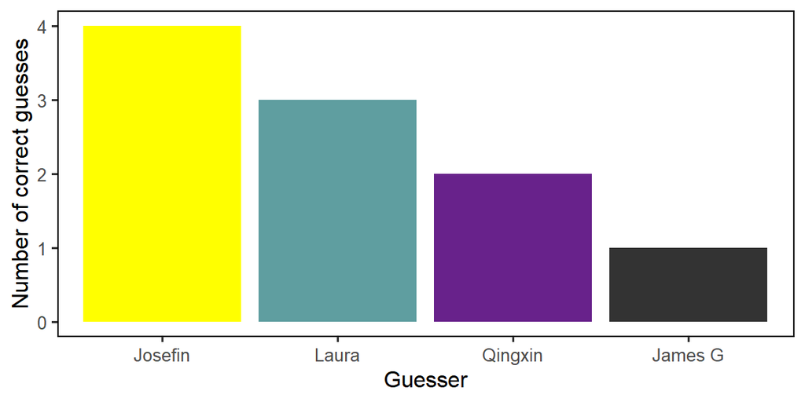

For each player, who guessed their answer correctly?

| Player | Who guessed correctly? |
| --- | --- |
| James G | Josefin, Laura |
| Jesse | Josefin, Qingxin |
| Josefin | Qingxin |
| Laura | Josefin |
| Linxi Zhu | Laura |
| Qingxin | James G, Josefin, Laura |

# Q2: Would you rather be a vampire, werewolf, witch, or slayer (like Buffy)?

| Player | Actual answer |
| --- | --- |
| James Chesko | Slayer |
| James G | Slayer |
| Laura | Slayer |
| Simone | Slayer |
| Jesse | Vampire |
| Qingxin | Vampire |
| Josefin | Witch |
| Linxi Zhu | Witch |
| Millie | Witch |

Who had the most correct answers?

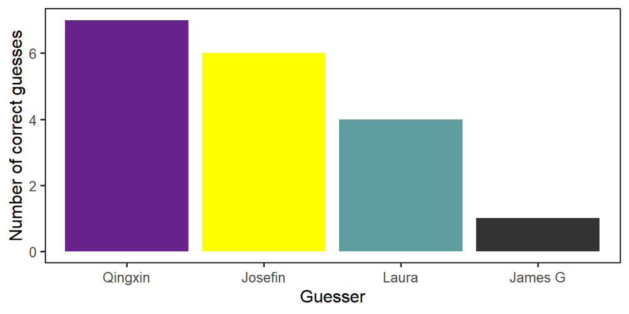

For each player, who guessed their answer correctly?

| Player | Who guessed correctly? |
| --- | --- |
| James Chesko | Josefin, Laura, Qingxin |
| Jesse | Josefin, Qingxin |
| Josefin | Laura, Qingxin |
| Laura | Josefin, Qingxin |
| Linxi Zhu | James G, Josefin, Laura, Qingxin |
| Millie | Josefin, Laura, Qingxin |
| Simone | Josefin, Qingxin |

# Q3: What famous person do you think is most likely to be an alien?

| Player | Actual answer |
| --- | --- |
| James Chesko | Tom Cruise |
| James G | X Æ A-12 |
| Jesse | kevin durant |
| Josefin | Donald Trump (I really hope no human is that stupid) |
| Laura | Trump advisor Stephen Miller |
| Linxi Zhu | N/A |
| Millie | elon musk |
| Qingxin | Lady Gaga |
| Simone | Ronaldo |

Who had the most correct answers?

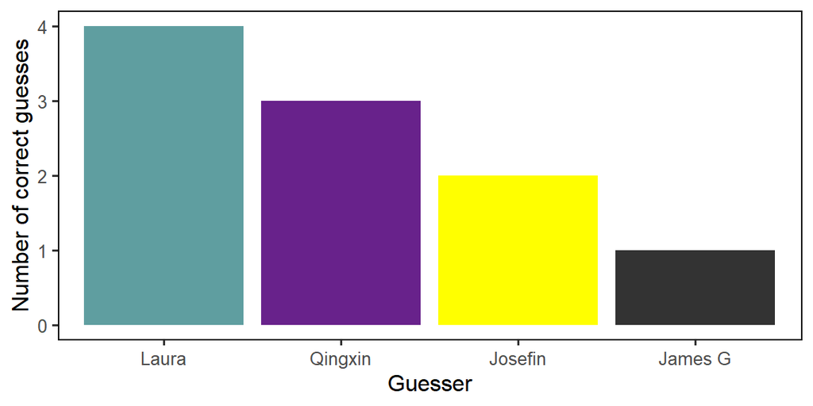

For each player, who guessed their answer correctly?

| Player | Who guessed correctly? |
| --- | --- |
| James Chesko | Laura |
| James G | Laura, Qingxin |
| Jesse | Josefin, Laura |
| Laura | Josefin |
| Linxi Zhu | Qingxin |
| Simone | James G, Laura, Qingxin |

# Q4: What lab meeting treat do you miss the most? Be specific, e.g., “maple bars” rather than “doughnuts”!

| Player | Actual answer |
| --- | --- |
| James Chesko | Only had treats two times so Laura S muffins! |
| James G | Maple bars |
| Jesse | Apple Fritter |
| Josefin | home made scones and jam |
| Laura | maple bars |
| Linxi Zhu | Scones |
| Millie | chocolate doughnut with sprinkles |
| Qingxin | Raspberry Glazed |
| Simone | Hardcore modeling with Danny and Laura |

Who had the most correct answers?

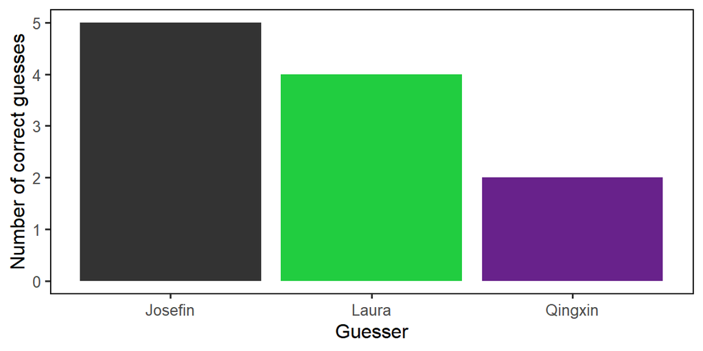

For each player, who guessed their answer correctly?

| Player | Who guessed correctly? |
| --- | --- |
| James Chesko | Josefin, Laura, Qingxin |
| Jesse | Josefin, Laura |
| Laura | Josefin |
| Linxi Zhu | Josefin, Laura |
| Simone | Josefin, Laura, Qingxin |

# Q5: In you were a YouTuber, what would your YouTube channel be about?

| Player | Actual answer |
| --- | --- |
| James Chesko | Ways to live without a car |
| James G | Making competitive Pokemon teams |
| Jesse | tastiest and most cost effective combinations of food from trader joes |
| Josefin | working out |
| Laura | coding in R |
| Linxi Zhu | Anime |
| Millie | eating ramen |
| Qingxin | nature scenes |
| Simone | Covid |

Who had the most correct answers?

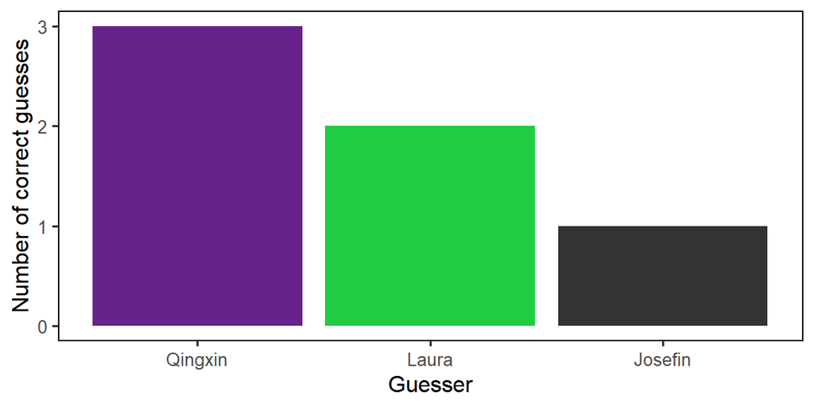

For each player, who guessed their answer correctly?

| Player | Who guessed correctly? |
| --- | --- |
| James Chesko | Qingxin |
| James G | Laura |
| Linxi Zhu | Josefin, Laura, Qingxin |
| Simone | Qingxin |

# Q6: What is one interesting thing about you that most people might not know?

| Player | Actual answer |
| --- | --- |
| James Chesko | Two middle names but not royalty |
| James G | I had a six-pack (abs) when I was 11 years old |
| Jesse | I learned french before english |
| Josefin | I scored a Quigley from 300 meters in Ghost Recon |
| Laura | I used to be a newspaper reporter. |
| Linxi Zhu | I can change my voice |
| Millie | i have strawberry milk-phobia! |
| Qingxin | I used to sing opera using opposite gender’s voice |
| Simone | Nothing |

Who had the most correct answers?

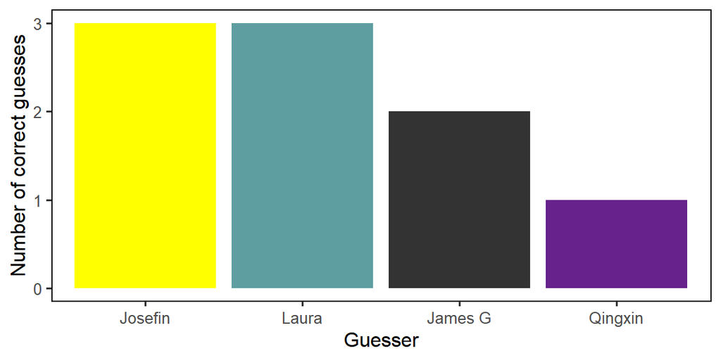

For each player, who guessed their answer correctly?

| Player | Who guessed correctly? |
| --- | --- |
| James Chesko | Laura |
| Jesse | James G, Josefin, Laura |
| Laura | Josefin, Qingxin |
| Linxi Zhu | Josefin, Laura |
| Millie | James G |

# Q7: Complete this sentence: “People love it when I make _____! It’s my signature dish!”

| Player | Actual answer |
| --- | --- |
| James Chesko | Grand Marnier Crepes |
| James G | Popcorn with the movie theater butter |
| Jesse | Shephards Pie |
| Josefin | Gingerbread cookies |
| Laura | lime meringue pie |
| Linxi Zhu | Saozi noodles |
| Millie | fried rice |
| Qingxin | Braised pork |
| Simone | Lasagna |

Who had the most correct answers?

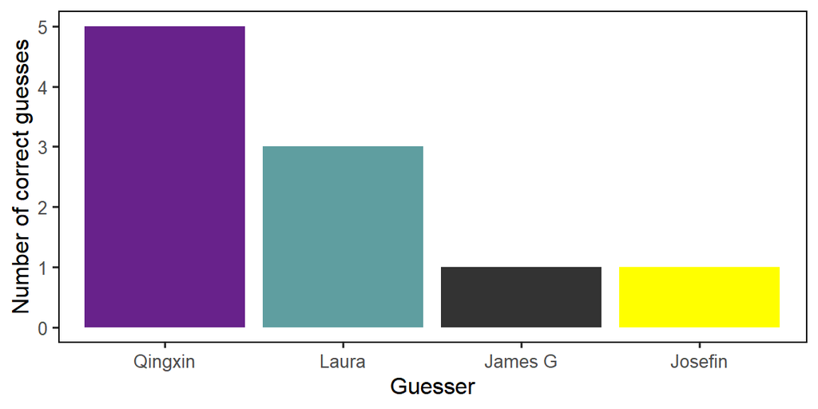

For each player, who guessed their answer correctly?

| Player | Who guessed correctly? |
| --- | --- |
| James G | Josefin, Laura, Qingxin |
| Jesse | Qingxin |
| Josefin | Laura, Qingxin |
| Laura | Qingxin |
| Linxi Zhu | Qingxin |
| Simone | James G, Laura |

# Q8: If there were no pandemic right now and funds weren’t an issue, where would you most like to vacation next?

| Player | Actual answer |
| --- | --- |
| James Chesko | Canada |
| James G | Japan |
| Jesse | Vietnam |
| Josefin | Patagonia |
| Laura | Thailand |
| Linxi Zhu | Japan |
| Millie | spain or japan |
| Qingxin | Hawaii |
| Simone | Argentina |

Who had the most correct answers?

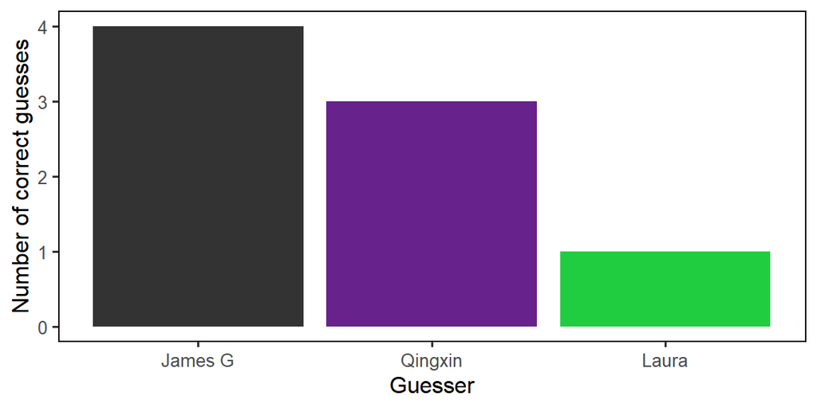

For each player, who guessed their answer correctly?

| Player | Who guessed correctly? |
| --- | --- |
| James G | Qingxin |
| Jesse | James G |
| Josefin | James G, Laura |
| Laura | James G, Qingxin |
| Linxi Zhu | James G, Qingxin |

# Overall scores

Number of correct answers:

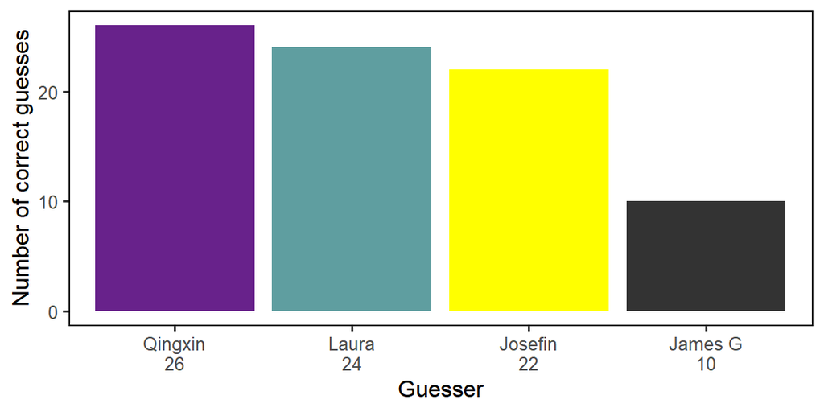

Who knows you best? Who guessed your answers correctly the most?

| Player | Known best by | Number of correct guesses |
| --- | --- | --- |
| James Chesko | Laura | 4 |
| James G | Laura | 4 |
| Jesse | Josefin | 5 |
| Josefin | Laura & Qingxin | 3 |
| Laura | Josefin | 5 |
| Linxi Zhu | Laura & Qingxin | 5 |
| Millie | James G & Josefin & Laura & Qingxin | 1 |
| Qingxin | James G & Josefin & Laura | 1 |
| Simone | Qingxin | 4 |